# Parameter Correlations in Monte Carlo GHG Inventory Uncertainty Analysis | Cattle GHG Uncertainty Calculator Help

This page describes how correlations between input parameters affect Monte Carlo simulation results in the tool, what the two correlation cards on the Simulate tab control, and how to interpret each option using two worked examples.

The principle: when two input parameters tend to move together in nature, the Monte Carlo sampler should reproduce that joint behaviour. Sampling them independently when they are correlated produces parameter combinations that do not occur in real systems, which biases the spread (though not the central estimate) of the simulated emissions distribution.

## Visualising correlation

Consider two parameters, with 1000 Monte Carlo samples of each, plotted as a scatter cloud: one point per iteration, the first parameter on the x-axis and the second on the y-axis. The three panels below show the same two marginal distributions under different correlation strengths:

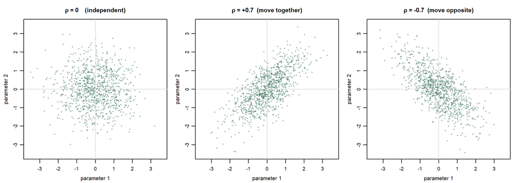

In the centre panel, when parameter 1 takes a high value, parameter 2 tends to be high as well. The cloud tilts upward. In the right-hand panel the relationship is reversed: high values of parameter 1 occur with low values of parameter 2, and the cloud tilts downward.

The marginal distribution of each parameter is identical across all three panels: the same range on each axis. Correlation does not change the distribution of either parameter on its own; it changes only which combinations of values occur together.

## Preserving marginal distributions (Iman–Conover method)

Real inventory parameters rarely follow symmetric normal distributions. Body weight is approximately symmetric, milk yield has a long right tail, and the methane conversion factor Y<sub>m</sub> is bounded between approximately 5% and 8%. A bivariate-normal sampler with a target correlation cannot reproduce these shapes.

The tool uses the Iman–Conover procedure (Iman & Conover 1982; IPCC 2006 Vol.1 Ch.3 §3.2.3.2). Each parameter is sampled from its specified marginal distribution (PERT, normal, lognormal, beta, etc.: as set in the Parameters sheet), and the samples are then re-ordered so that the *rank* correlation across pairs matches the target. The marginal distribution of each parameter is preserved exactly; only the joint pattern of ranks changes.

The following panels show two parameters with identical right-skewed Beta distributions, sampled independently (left) and with rank correlation ρ = −0.5 imposed via Iman–Conover (right):

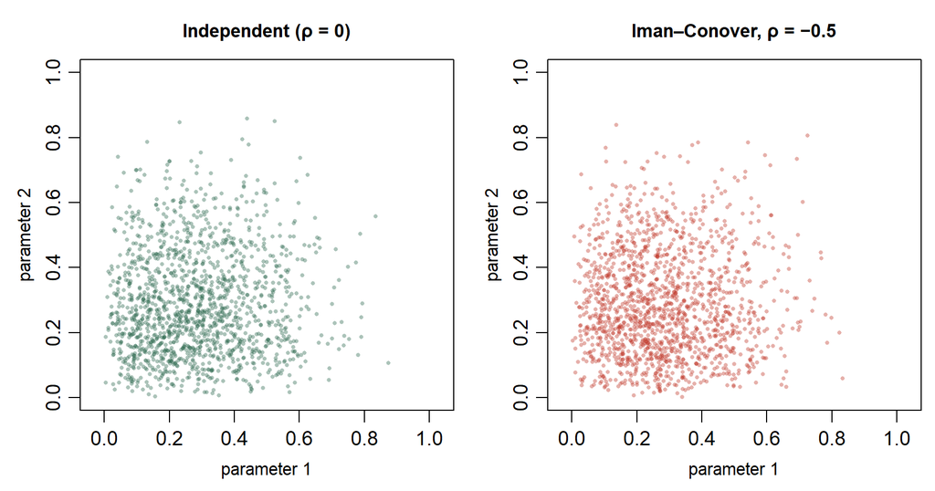

The right-hand cloud tilts downward, but the lopsided shape of each marginal axis is unchanged. This is the defining property of the Iman–Conover procedure: marginal distributions are preserved exactly, and only the joint pattern of ranks is modified.

## Implications for the IPCC equations

Several pairs of IPCC Tier 2 input parameters are biologically correlated. The most pronounced is between digestible energy (`DE`) and the methane conversion factor `Ym`: when feed quality rises (higher `DE`), less of the ingested energy is lost as methane (lower `Ym`); when feed quality falls, `Ym` rises. The two parameters enter the enteric-CH<sub>4</sub> equation as a product, so the joint behaviour of `DE × Ym` directly shapes the emissions distribution.

Imposing ρ = −0.5 between `DE` and `Ym` excludes the implausible combinations and changes the shape of the product distribution as follows:

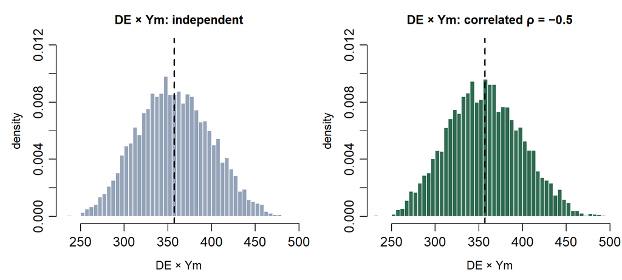

First, the means of the two histograms (dashed vertical lines) are essentially identical. By construction, the Iman–Conover procedure preserves each marginal distribution, including its mean, so imposing correlation does not shift the central estimate of any function of those parameters.

Within the full IPCC Tier 2 equation chain, the structural-defaults preset applies seven such correlations alongside roughly a dozen independent inputs. The individual effects partially cancel, and the net result on the 95% margin of error of total CO<sub>2</sub>eq is typically a few percentage points. The mean of the total is preserved.

## Country X (smallholder dairy)

Country X is the built-in dairy example: 500,000 head, milking cows on improved pasture and concentrate supplement, with `DE ≈ 55%`, `Milk ≈ 4 kg per lactating cow per day`, and `Ym ≈ 6.5%`. Diet quality and methane conversion both vary substantially across the herd, which is the condition under which the `DE ↔︎ Ym` correlation has the largest effect on the simulated emissions distribution.

Each row in the table below is a full 3000-iteration simulation of Country X. Only the correlation mode varies between rows.

| Mode | Mean total CO₂eq (t) | 95% CI lower (t) | 95% CI upper (t) | 95% MoE (%) |
| --- | --- | --- | --- | --- |
| No correlations | 1,278,297 | 992,900 | 1,639,251 | 25.3 |
| Structural defaults | 1,278,334 | 973,001 | 1,648,670 | 26.4 |
| Time-series (auto) | 1,275,686 | 1,003,880 | 1,611,562 | 23.8 |
| Manual (example template) | 1,278,723 | 970,339 | 1,646,870 | 26.5 |

The same comparison can be reproduced directly on a user-supplied inventory: enabling the “Compare with/without correlations” option on the Simulate tab produces a side-by-side bar chart of the 95% margin of error with the selected correlation mode (green bars) and with all correlations disabled (grey bars).

## Country Y (extensive pastoral, no dairy)

Country Y is 2.4 million head of beef cattle on rangeland. `DE` is lower (around 50%, with a wider uncertainty bound), milk yield is essentially zero (calves only), and the population is dominated by adult animals on year-round grazing.

| Mode | Mean total CO₂eq (t) | 95% CI lower (t) | 95% CI upper (t) | 95% MoE (%) |
| --- | --- | --- | --- | --- |
| No correlations | 5,518,982 | 3,765,490 | 7,790,259 | 36.5 |
| Structural defaults | 5,535,904 | 3,615,333 | 7,943,533 | 39.1 |
| Time-series (auto) | 5,410,777 | 4,825,476 | 6,046,399 | 11.3 |
| Manual (example template) | 5,535,491 | 3,608,284 | 7,976,637 | 39.5 |

The headline shift in both countries is shown side by side below:

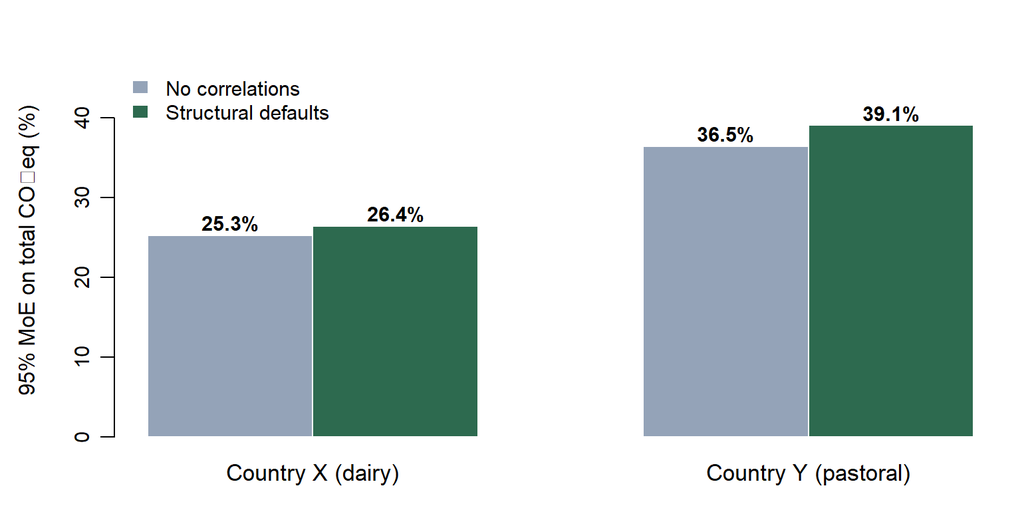

## The seven pairs in the structural-defaults preset

The “Structural defaults” mode applies seven parameter-pair correlations drawn from published livestock-science literature. Each pair, its assigned ρ value, and its source are listed below:

- **BW ↔︎ MW** (ρ = +0.50). Cattle with above-average adult body weight typically also exceeded the average at younger ages, following standard allometric growth curves (Brody 1945). Used in IPCC Vol.4 Ch.10 Eq 10.3. The value 0.50 reflects the typical case in which BW and MW come from different sources (BW from a livestock census, MW from a breed reference); when both come from the same animal-condition survey, a higher value can be set via the manual matrix.
- **BW ↔︎ WG** (ρ = +0.40). In well-fed adult cattle (dairy or beef finishing systems), heavier animals tend to gain weight more rapidly. NRC (2001) joint regression of body weight and average daily gain. The sign of this correlation is system-dependent: in growing-young-stock systems with feed limitation, BW and WG can be negatively correlated.
- **Milk ↔︎ Fat** (ρ = −0.30). The dilution effect: higher daily milk yield is associated with lower fat content per litre. Reported across the dairy genetics literature (Wilmink 1987; VandeHaar 1998), with within-herd values typically between −0.20 and −0.40.
- **Milk ↔︎ BW** (ρ = +0.30). High-producing dairy breeds are physically larger (e.g. Holstein ~650 kg, ~30 kg/day vs Jersey ~450 kg, ~20 kg/day). NRC Dairy (2001).
- **Milk ↔︎ DE** (ρ = +0.30). Higher feed digestibility increases nutrient availability, which lifts milk yield. The effect is strongest in concentrate-fed dairy systems. NRC Dairy (2001) Ch. 2.
- **DE ↔︎ CP** (ρ = +0.50). Feed-quality co-variation: high-quality forages tend to have both high digestibility and high crude protein. Cross-feedstuff correlations of 0.4–0.7 are documented in NRC, INRA, and Feedipedia.
- **DE ↔︎ Y<sub>m</sub>** (ρ = −0.50). The largest-magnitude correlation in the preset and the dominant contributor to the headline MoE shift in dairy systems. IPCC 2019 Refinement Eq 10.21 expresses Y<sub>m</sub> as an explicit decreasing function of `DE`; observational meta-analyses (Niu et al. 2018; Hristov et al. 2013) report cross-diet slopes consistent with ρ ≈ −0.50.

The structure of the preset matrix is visualised below:

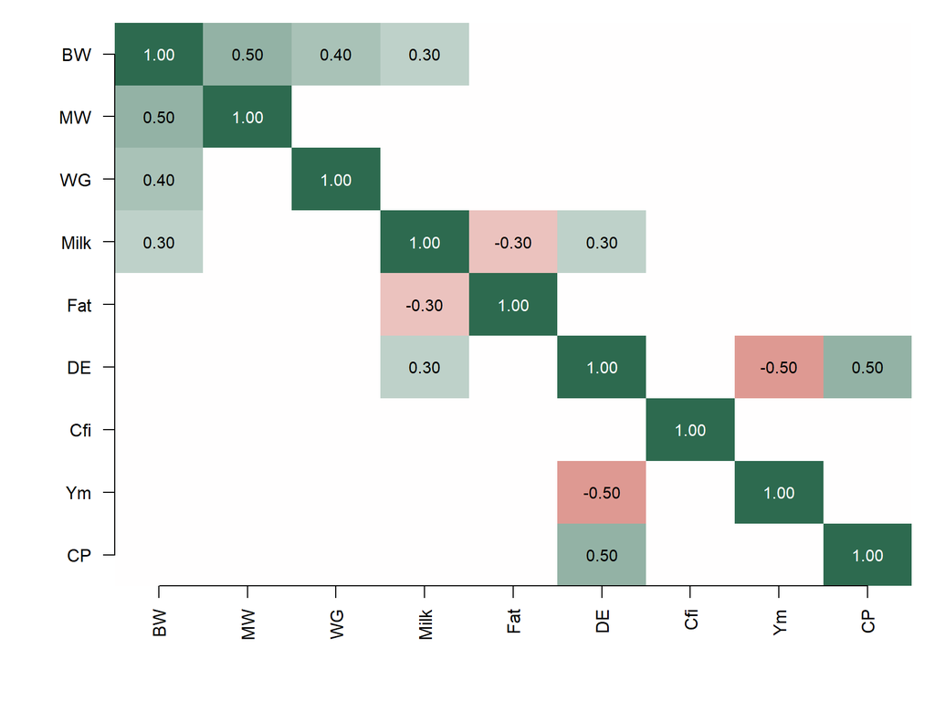

Green cells denote positive correlations, red cells negative, and white cells independence. The preset is intentionally sparse: only the seven pairs with documented published evidence are non-zero. All other parameter pairs are sampled independently unless overridden by a user-supplied matrix.

## Two different correlations, and which one matters more

This page describes two settings that are both called correlation and are easy to confuse.

The **correlation mode** covers relationships *between different parameters within a group*: body weight with mature weight, digestibility with methane conversion, and so on. Its effect on the headline figure is real but modest, typically widening the interval by 3 to 10 per cent on a real inventory.

**Inputs shared between groups** covers something different: the *same parameter reused across groups*. If one IPCC default or one regional study supplies a value used by many groups, that is a single estimate applied repeatedly, and its error moves every group together. Its effect is not modest. On the test in Common pitfalls below, treating shared values independently took the reported margin of error from 25.1 per cent to 1.5 per cent on the same data.

The two are applied separately, and in the current version they are mutually exclusive for any parameter that is shared: where a coefficient is drawn once and handed to several groups, the within-group correlation matrix cannot also reorder it. Where the two would conflict, the cross-group treatment takes precedence, because it is the larger and more consequential effect.

## Selecting an activity-data correlation mode

The left-hand card on the Simulate tab offers four options:

**No correlations.** The strict IPCC Approach-2 default, applicable when activity-data sources are independent or when a conservative baseline is required.

**Structural defaults (expert-elicited).** Applies the seven biological pairs documented above. Suitable for single-year inventories without a multi-year time series of feed quality or herd structure.

**From template (auto, time-series).** Computes a Spearman rank-correlation matrix from the user’s `Parameter_TimeSeries` sheet, with first-difference detrending applied internally to remove shared long-run growth. Requires at least five years of populated data; the radio button is disabled in the UI when this condition is not met.

**Manual (CSV upload).** Uses a user-supplied square correlation matrix, intended for cases where a published matrix from a similar inventory or an expert-elicitation result is available. A template is provided in the panel.

## Emission-factor correlations (right-hand card)

The Simulate tab includes two correlation cards. The left-hand card, described above, controls correlations between **activity-data** parameters (herd size, body weight, milk yield, feed quality: quantities measured from the population). The right-hand card controls correlations between **emission-factor coefficients** (Y<sub>m</sub>, B<sub>o</sub>, MCF, EF3, EF4, EF5, fixed quantities sourced from published studies rather than from a per-population survey).

The two cards are separated because the underlying mechanisms differ. Activity-data correlations arise from biological co-variation across animals and feed. Emission-factor correlations arise from shared methodological bias in the published values: for example, when several coefficients are calibrated against a common regional dataset.

### The three coefficient blocks

The right-hand card groups the IPCC coefficients into three blocks based on the scientific literature they originate from. A within-block correlation ρ can be applied to represent shared bias within a block; correlation across blocks is fixed at zero on the assumption that the three literatures are independent.

| Block | Coefficients | Common literature source |
| --- | --- | --- |
| **Energy** | Cfi, Ca, C, Cp, Y<sub>m</sub> | Rumen-fermentation and animal-energetics studies (IPCC Vol.4 Ch.10 §10.2). |
| **Manure-CH<sub>4</sub>** | B<sub>o</sub>, MCF, ASH | Biogas-potential and lagoon studies. |
| **Manure-N** | EF3, EF4, EF5, Frac_GasMS, Frac_LeachMS, UE | Soil-emissions and N-volatilisation studies. |

### Behaviour of the within-block ρ slider

When “Block-structured EF correlation” is selected and the energy-block slider is set to ρ = 0.3, the sampler treats the five energy coefficients as sharing a common bias term of moderate strength. An iteration in which Y<sub>m</sub> samples above its central value will also draw Cfi slightly above its central value (and similarly for the other energy coefficients), with the magnitude of the offset proportional to ρ.

The figure below shows the joint sample cloud of Y<sub>m</sub> and Cfi under three slider settings:

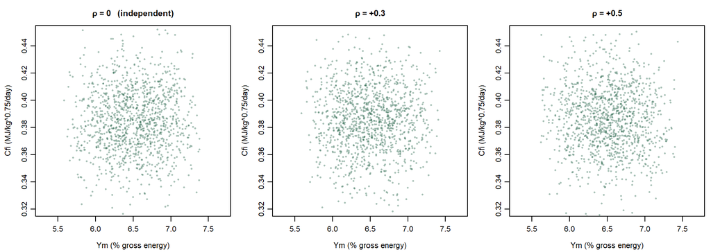

### Effect on the headline emissions estimate

The figure below shows the 95% margin of error of total CO<sub>2</sub>eq for Country X under a range of correlation configurations:

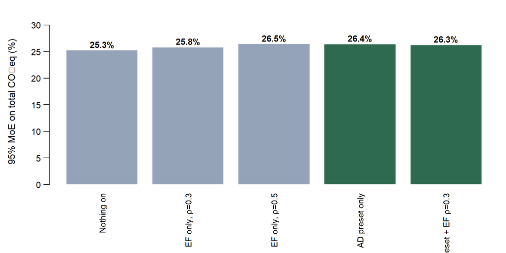

### Guidance on when to enable EF correlations

The block-structured EF correlation is appropriate only when there is reason to believe that several emission-factor coefficients share a common methodological bias. The IPCC defaults are aggregated across many independent studies, so no single bias dominates; when the user’s emission factors are taken from IPCC defaults, the EF correlation should remain off. Similarly, if the emission factors are sourced from country-specific measurements performed at different laboratories or in different years, the corresponding errors can be treated as independent.

EF correlation at ρ = 0.3 is reasonable when several coefficients within a block originate from a single methodological source: for example, when all energy-equation coefficients (Cfi, Ca, Y<sub>m</sub>, and others) are drawn from a single national feeding trial or a single regional rumen database. The slider interpretation displayed under each slider categorises ρ in four bands: 0 (independent), up to 0.15 (weak shared bias), 0.16 to 0.35 (moderate shared bias), and above 0.35 (strong shared bias requiring documented justification).

The same reasoning applies to the manure-CH<sub>4</sub> block (B<sub>o</sub>, MCF, ASH) and the manure-N block (EF3, EF4, EF5, Frac_GasMS, Frac_LeachMS, UE): engage a non-zero ρ only when the constituent coefficients are known to share a common source.

If the “Block-structured EF correlation” mode is selected but all three sliders are left at zero, an amber warning appears under the sliders. In this configuration the simulation behaves identically to the “No EF correlations” mode; the warning indicates that the user should either move at least one slider above zero or switch back to the default mode.

## Common pitfalls

- **Assuming a smaller margin of error means a better inventory.** It can mean the opposite. If the same coefficient value is reused across many groups and each group samples it independently, the errors cancel against each other and the reported uncertainty shrinks as the inventory is disaggregated more finely. Holding the herd, the parameters and the uncertainty inputs completely fixed and varying only the number of groups gives 25.1% on one group, 12.5% on four, 6.3% on sixteen, 3.1% on sixty-four and 1.5% on 251. The data never changed. This is what the **Inputs shared between groups** setting exists to prevent, and why it defaults to treating a shared value as a single estimate. A reported uncertainty that looks implausibly tight for a Tier 2 inventory (well under 10%) on a finely disaggregated file is the symptom to look for.
- **Expecting the mean to change.** Correlations modify the spread of the emissions distribution but preserve the central estimate to within Monte Carlo sampling noise. A mean shift of more than a few tenths of a percent across correlation modes is typically not a correlation effect but a separate issue (most often related to parameter rebroadcasting).
- **Selecting “From template (auto)” with an empty `Parameter_TimeSeries` sheet.** In earlier versions this configuration silently reverted to no correlations. The radio button is now disabled when the sheet contains no data, and the Run button blocks with an explicit error if stale state slips through. Identical heights for the green and grey bars in the comparison chart are a symptom of this configuration.
- **Selecting “Block-structured EF correlation” with all three sliders at zero.** This produces a no-op identical to the default mode. An amber warning appears under the sliders; the user should move at least one slider above zero or switch back to “No EF correlations”.
- **Modifying row or column headers in the manual matrix.** Names that do not match the canonical entries in `PARAM_CATALOGUE` are dropped silently during import. The example template provided in the panel contains the canonical names and should be used as the starting point.
- **Concerns about positive-definiteness.** If the uploaded matrix is not positive-definite, the tool automatically projects it onto the nearest positive-definite correlation matrix and reports any entry that shifts by more than 0.01. Manual construction of a positive-definite matrix is not required.
- **Interpreting a small headline effect as an error.** A single correlated pair within a multiplicative chain of approximately thirteen inputs typically shifts the 95% margin of error by only a few percent. This is the expected mathematical behaviour. Larger effects require either a richer multi-year time series (the “From template (auto)” mode aggregates many correlated pairs simultaneously) or genuinely wide per-parameter uncertainty bounds.

## Evaluating the effect on a user-supplied inventory

Selecting the “Compare with/without correlations” option on the Simulate tab before running the simulation produces a side-by-side bar chart on the Results tab titled “Effect of Correlations on Uncertainty”. The green bars show the 95% margin of error under the selected correlation configuration, and the grey bars show the same simulation with all correlations disabled. The difference between the two bars represents the effect of correlations on the user’s specific inventory.

The Country X and Country Y examples in this document illustrate the typical magnitude of this effect, but the precise gap depends on the per-parameter uncertainty bounds and the sub-category composition of the inventory under analysis.

### Related material

- Methodology document, §Correlation Structure: the full equations behind each preset pair, the Iman–Conover sampling procedure, and the rejected pairs (N↔︎BW, Cfi↔︎Ca, Milk↔︎pct_pregnant) with reasons.
- User Guide, §Correlations (Simulate tab): step-by-step workflow including how to download the manual-entry CSV template.
- IPCC 2006 Vol.1 Ch.3 §3.2.3.2: the restricted-pairing rank-correlation procedure (Iman & Conover 1982) that the tool implements.